# Analysis of the Factors that Influence Wine Quality

Brian Campbell

September 16, 2018

========================================================

## Pre-Analysis

> This installs and loads the necessary packages to conduct the analysis.

[output not shown]

[output not shown]

[output not shown]

[output not shown]

[output not shown]

[output not shown]

[output not shown]

> This sets the working directory and insures that all columns in the data set are labeled.

```
## [1] "C:/Users/bgcam/OneDrive/Documents/Udacity Degree/Semester 2/Part 2/Project 6"
```

```
##   X fixed.acidity volatile.acidity citric.acid residual.sugar chlorides
## 1 1           7.4             0.70        0.00            1.9     0.076
## 2 2           7.8             0.88        0.00            2.6     0.098
## 3 3           7.8             0.76        0.04            2.3     0.092
## 4 4          11.2             0.28        0.56            1.9     0.075
## 5 5           7.4             0.70        0.00            1.9     0.076
## 6 6           7.4             0.66        0.00            1.8     0.075
##   free.sulfur.dioxide total.sulfur.dioxide density   pH sulphates alcohol
## 1                  11                   34  0.9978 3.51      0.56     9.4
## 2                  25                   67  0.9968 3.20      0.68     9.8
## 3                  15                   54  0.9970 3.26      0.65     9.8
## 4                  17                   60  0.9980 3.16      0.58     9.8
## 5                  11                   34  0.9978 3.51      0.56     9.4
## 6                  13                   40  0.9978 3.51      0.56     9.4
##   quality
## 1       5
## 2       5
## 3       5
## 4       6
## 5       5
## 6       5
```

```
##  [1] "wine.id.num"          "fixed.acidity"        "volatile.acidity"
##  [4] "citric.acid"          "residual.sugar"       "chlorides"
##  [7] "free.sulfur.dioxide"  "total.sulfur.dioxide" "density"
## [10] "pH"                   "sulphates"            "alcohol"
## [13] "quality"
```

```
##   wine.id.num fixed.acidity volatile.acidity citric.acid residual.sugar
## 1           1           7.4             0.70        0.00            1.9
## 2           2           7.8             0.88        0.00            2.6
## 3           3           7.8             0.76        0.04            2.3
## 4           4          11.2             0.28        0.56            1.9
## 5           5           7.4             0.70        0.00            1.9
## 6           6           7.4             0.66        0.00            1.8
##   chlorides free.sulfur.dioxide total.sulfur.dioxide density   pH
## 1     0.076                  11                   34  0.9978 3.51
## 2     0.098                  25                   67  0.9968 3.20
## 3     0.092                  15                   54  0.9970 3.26
## 4     0.075                  17                   60  0.9980 3.16
## 5     0.076                  11                   34  0.9978 3.51
## 6     0.075                  13                   40  0.9978 3.51
##   sulphates alcohol quality
## 1      0.56     9.4       5
## 2      0.68     9.8       5
## 3      0.65     9.8       5
## 4      0.58     9.8       6
## 5      0.56     9.4       5
## 6      0.56     9.4       5
```

```
## 'data.frame':    1599 obs. of  13 variables:
##  $ wine.id.num         : int  1 2 3 4 5 6 7 8 9 10 ...
##  $ fixed.acidity       : num  7.4 7.8 7.8 11.2 7.4 7.4 7.9 7.3 7.8 7.5 ...
##  $ volatile.acidity    : num  0.7 0.88 0.76 0.28 0.7 0.66 0.6 0.65 0.58 0.5 ...
##  $ citric.acid         : num  0 0 0.04 0.56 0 0 0.06 0 0.02 0.36 ...
##  $ residual.sugar      : num  1.9 2.6 2.3 1.9 1.9 1.8 1.6 1.2 2 6.1 ...
##  $ chlorides           : num  0.076 0.098 0.092 0.075 0.076 0.075 0.069 0.065 0.073 0.071 ...
##  $ free.sulfur.dioxide : num  11 25 15 17 11 13 15 15 9 17 ...
##  $ total.sulfur.dioxide: num  34 67 54 60 34 40 59 21 18 102 ...
##  $ density             : num  0.998 0.997 0.997 0.998 0.998 ...
##  $ pH                  : num  3.51 3.2 3.26 3.16 3.51 3.51 3.3 3.39 3.36 3.35 ...
##  $ sulphates           : num  0.56 0.68 0.65 0.58 0.56 0.56 0.46 0.47 0.57 0.8 ...
##  $ alcohol             : num  9.4 9.8 9.8 9.8 9.4 9.4 9.4 10 9.5 10.5 ...
##  $ quality             : int  5 5 5 6 5 5 5 7 7 5 ...
```

## Data Set Summary

> The data set, wineQualityReds.csv, stores information about red wines. It contains 1,599 observations of wine. The input variables are properties of the wine (IE PH values, residual sugar, and total sulfur dioxide), all of which are quantitative variables with the exception of wine ID number. The output variable is the quality variable. Quality is rated on a scale from 0-10, 0 being the worst, and quality is derived from the median quality rating of at least three wine experts.

> **Data Set Summary Source:** Source 2 in the Sources Section.

## Univariate Plots Section

> **Histogram of “fixed.acidity”**

```
##    Min. 1st Qu.  Median    Mean 3rd Qu.    Max.
##    4.60    7.10    7.90    8.32    9.20   15.90
```

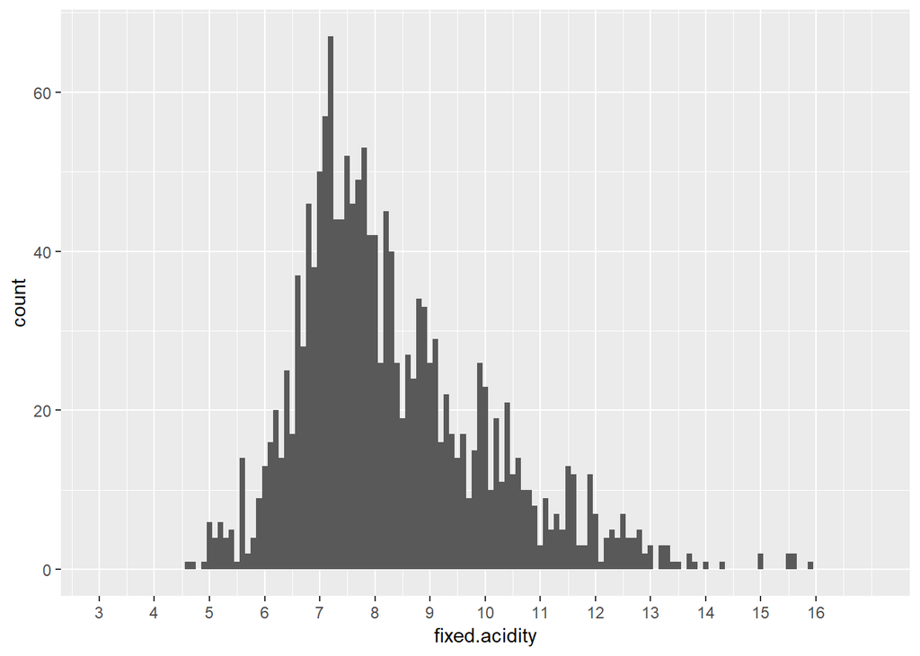

> > **Histogram of “fixed.acidity”**: The data follows a normal distribution that is skewed right. Median fixed acidity levels are 7.90, while the inner quartile range is 7.10 - 9.20.

> **Histogram of “volatile.acidity”**

```
##    Min. 1st Qu.  Median    Mean 3rd Qu.    Max.
##  0.1200  0.3900  0.5200  0.5278  0.6400  1.5800
```

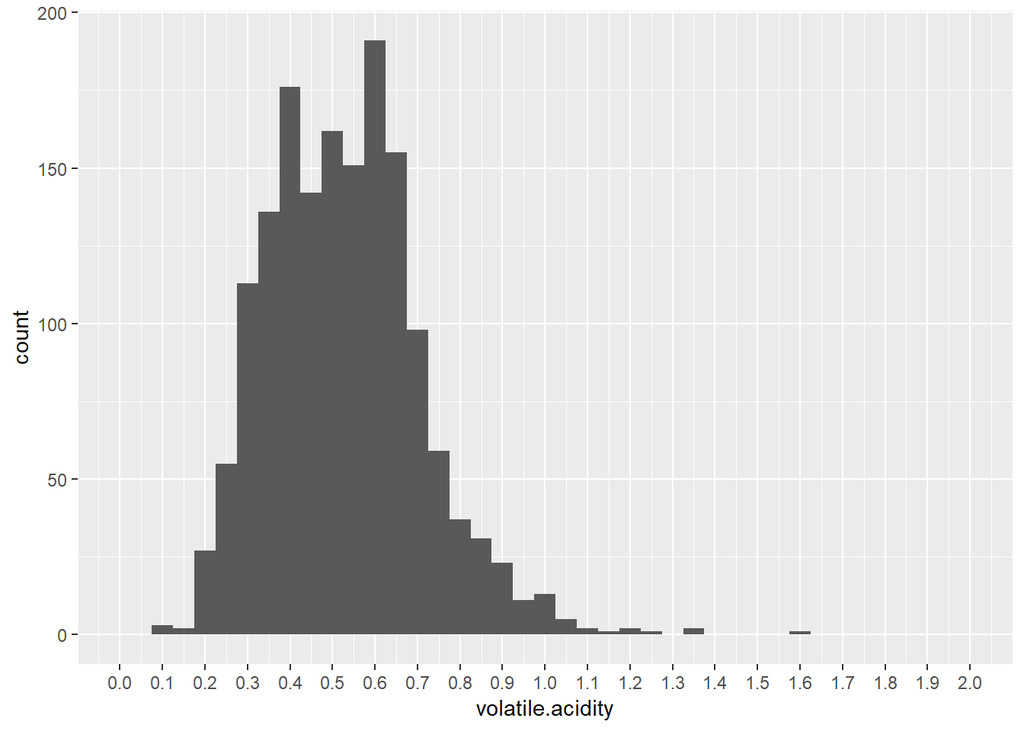

> > **Histogram of “volatile.acidity”**: The data is bimodally distributed with a slight skew to the right. The median level of volatile acidity is 0.52. The inner quartile range of volatile acidity is 0.39 - 0.64.

> **Histogram of “citric.acid”**:

```
##    Min. 1st Qu.  Median    Mean 3rd Qu.    Max.
##   0.000   0.090   0.260   0.271   0.420   1.000
```

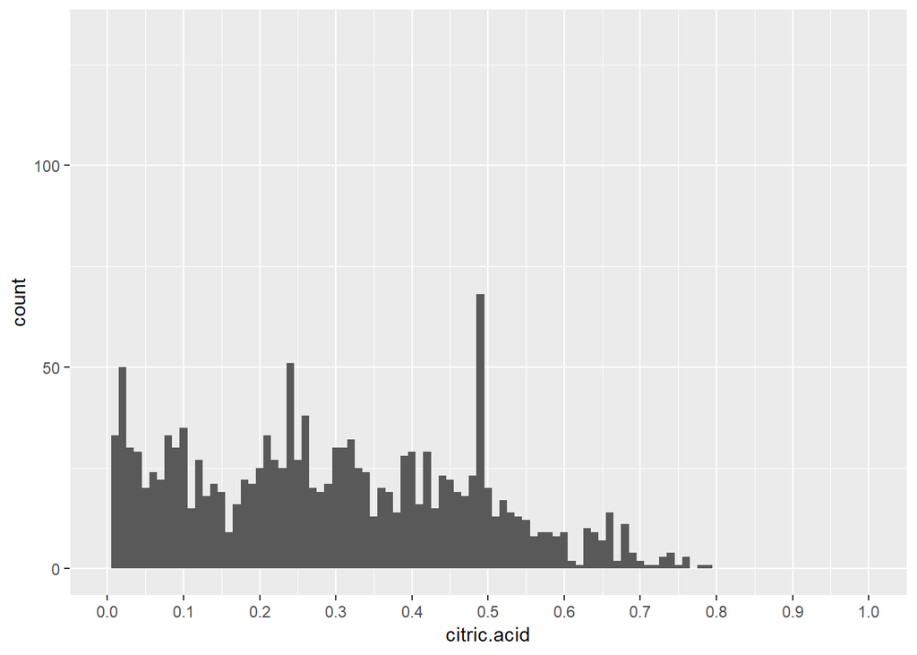

> > **Histogram of “citric.acid”**: The data is trimodal. The median level of citric acid 0.260. The inner quartile range is from 0.090 - 0.420.

> **Histogram of “residual.sugar”**

```
##    Min. 1st Qu.  Median    Mean 3rd Qu.    Max.
##   0.900   1.900   2.200   2.539   2.600  15.500
```

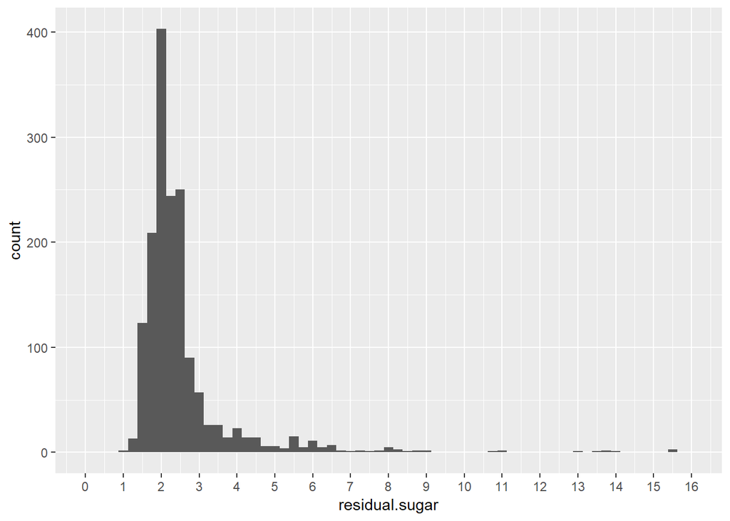

> > **Histogram of “residual.sugar”**: The data is normally distributed with a slight skew to the right with some outliers. The median level of residual sugar is 2.20. The inner quartile range is from 1.90 - 2.60.

> **Histogram of “chlorides”**

```
##    Min. 1st Qu.  Median    Mean 3rd Qu.    Max.
## 0.01200 0.07000 0.07900 0.08747 0.09000 0.61100
```

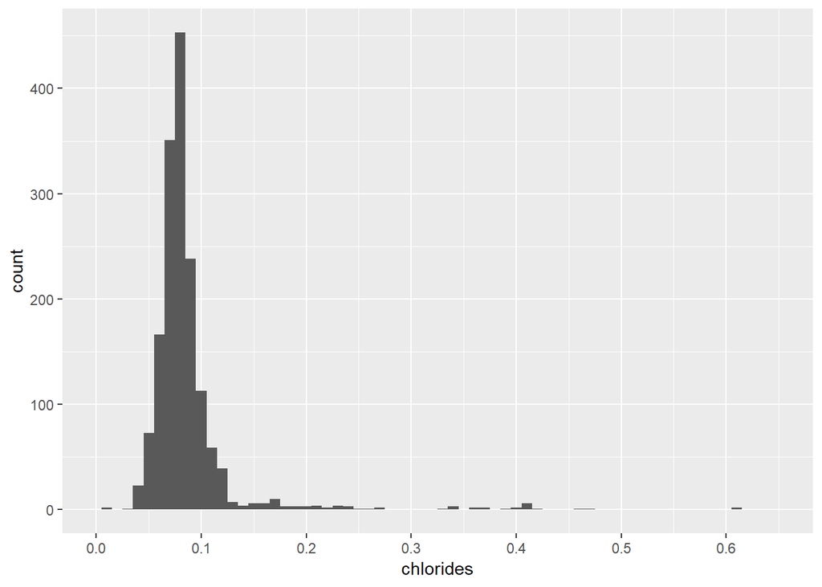

> > **Histogram of “chlorides”**: The data is normally distributed with a slight skew to the right with some outliers. The median level of chlorides is 0.079. The inner quartile range is from 0.070 - 0.090.

> **Histogram of “free.sulfur.dioxide”**

```
##    Min. 1st Qu.  Median    Mean 3rd Qu.    Max.
##    1.00    7.00   14.00   15.87   21.00   72.00
```

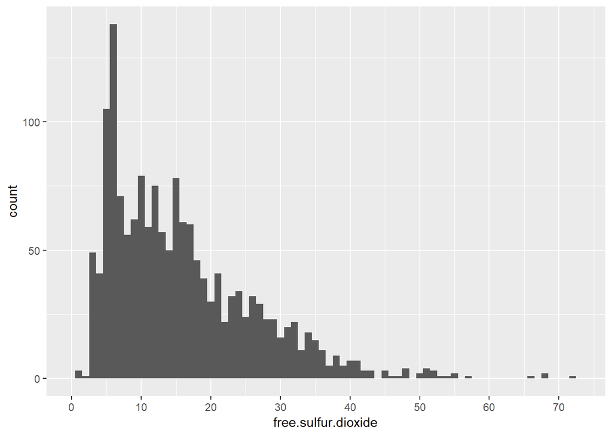

> > **Histogram of “free.sulfur.dioxide”**: The data is skewed right. The median level of sulfur dioxide is 14. The inner quartile range of sulfur dioxide is from 7 - 21.